# HW 5

Jillian

2023-03-03

# Assignment

Group members: Jillian Egland  
repo link: https://github.com/jcegland/DS202-Spring2023

Workflow paragraph:  
The workflow of this project was fairly smooth. Once I started working on it and looking at the data it was easy to figure out how the data fit together and how to create graphs to make sense of the data. The questions in the slides were helpful in guiding the exploration process of the data and allowed me to systematically visualize the data.

# importing data

```r
library(ggplot2)
choco <- read.csv("https://ds202-at-isu.github.io/labs/data/choco.csv")
head(choco)
```

```
##    Company Specific.Bean.Origin  REF Review.Date Cocoa.Pct Company.Location
## 1 A. Morin          Agua Grande 1876        2016        63           France
## 2 A. Morin                Kpime 1676        2015        70           France
## 3 A. Morin               Panama 1011        2013        70           France
## 4 A. Morin           Madagascar 1011        2013        70           France
## 5 A. Morin               Brazil 1011        2013        70           France
## 6 A. Morin             Equateur 1011        2013        70           France
##   Rating Bean.Type Broad.Bean.Origin
## 1   3.75                    Sao Tome
## 2   2.75                        Togo
## 3   2.75                      Panama
## 4   3.00   Criollo        Madagascar
## 5   3.25                      Brazil
## 6   3.75                     Ecuador
```

```r
str(choco)
```

```
## 'data.frame':    1852 obs. of  9 variables:
##  $ Company             : chr  "A. Morin" "A. Morin" "A. Morin" "A. Morin" ...
##  $ Specific.Bean.Origin: chr  "Agua Grande" "Kpime" "Panama" "Madagascar" ...
##  $ REF                 : int  1876 1676 1011 1011 1011 1011 1015 1015 1015 1015 ...
##  $ Review.Date         : int  2016 2015 2013 2013 2013 2013 2013 2013 2013 2013 ...
##  $ Cocoa.Pct           : num  63 70 70 70 70 70 70 70 70 70 ...
##  $ Company.Location    : chr  "France" "France" "France" "France" ...
##  $ Rating              : num  3.75 2.75 2.75 3 3.25 3.75 2.75 3 3.25 4 ...
##  $ Bean.Type           : chr  "" "" "" "Criollo" ...
##  $ Broad.Bean.Origin   : chr  "Sao Tome" "Togo" "Panama" "Madagascar" ...
```

# Question Set 1

1. What is the overall number of chocolate bars rated?
   - 1852
2. How does the number of ratings depend on the year? Draw a bar chart of the number of reports.
   - number of bars reviewed increased in the years up till 2015 then decreased the next two years

```r
# total bars rated
nrow(choco)
```

```
## [1] 1852
```

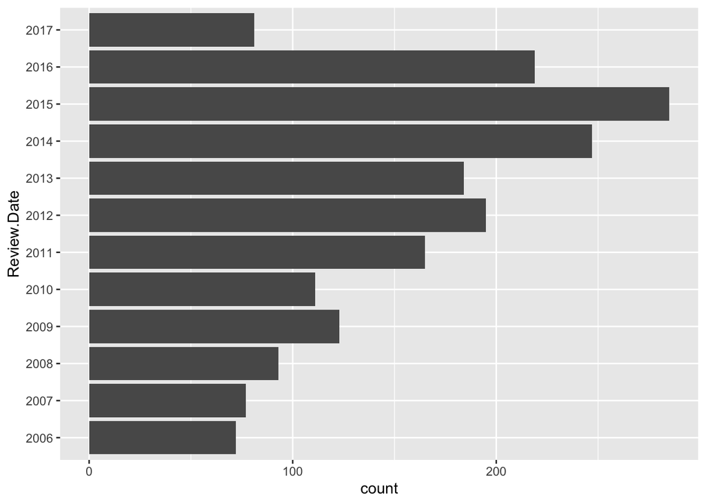

```r
choco$Review.Date=as.factor(choco$Review.Date)


ggplot(choco, aes(x=Review.Date)) + geom_bar() + coord_flip()
```

# Question Set 2

(provide at least one graphic as basis for the answers )  
1. How are ratings distributed? Draw a histogram of ratings and describe it. Don’t forget to mention outliers, if there are any.  
* unimodal, slightly skewed left, a few outliers on either end  
2. Do ratings depend on the cocoa percentage of a chocolate bar?  
* There doesn’t appear to be any relationship between percentages and ratings  
3. How do ratings compare across different company locations? Focus on the three locations with the most ratings:  
* average rating and max rating are the same for all three companies. USA and France have the same minimum. USA and Canada have the same IQR, but the middle 50% of the data for Canada is higher than the other 2 countries.

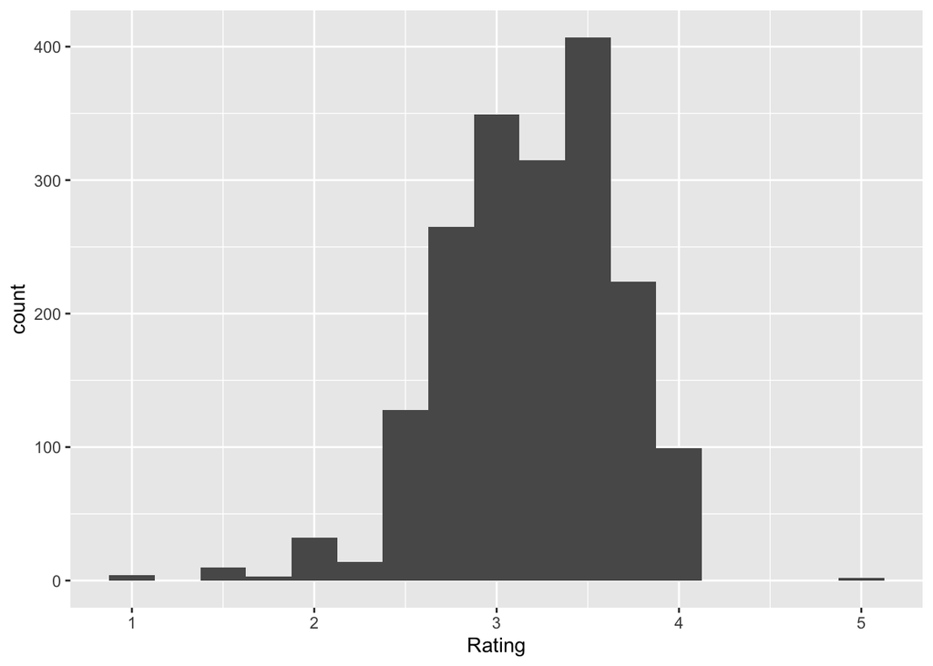

```r
# 1
ggplot(choco, aes(x=Rating)) + geom_histogram(binwidth=.25)
```

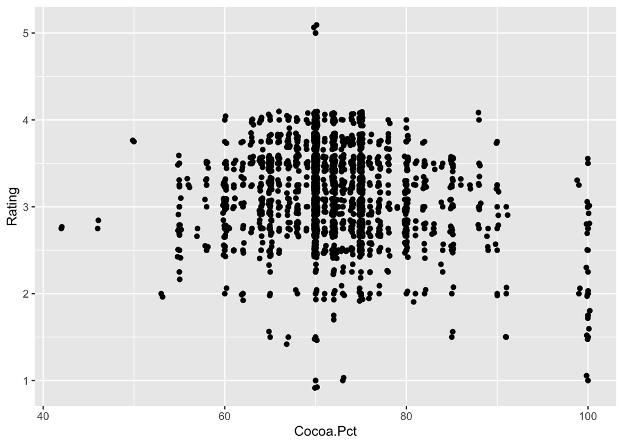

```r
# 2
ggplot(choco, aes(x=Cocoa.Pct, y=Rating)) + geom_point() + geom_jitter()
```

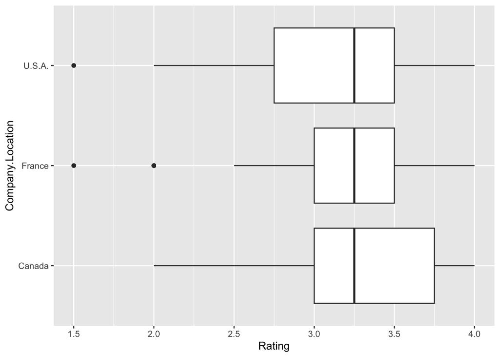

```r
top3 <- dplyr::filter(choco, Company.Location %in% c("U.S.A.", "France", "Canada"))

# 3
ggplot(top3, aes(x=Company.Location, y=Rating)) + geom_boxplot() + coord_flip()
```

# My Question

1. Question
   - do certain companies work more with certain percentages?
2. Graphs
3. Conclusion
   - Canada and USA have the same median percentage. USA seems to work with the widest range because of the large amount of outliers on either end of the boxplot. France works with the widest IQR of percentages.

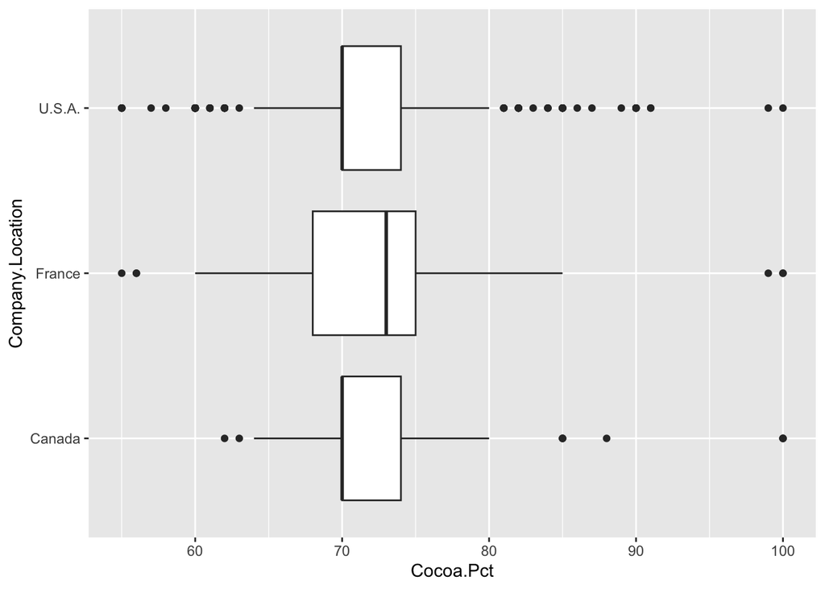

```r
ggplot(top3, aes(x=Company.Location, y=Cocoa.Pct)) + geom_boxplot() + coord_flip()
```